# 01做计算

- 2025.02.23
- 完成前七个ppt

1.print输出

```python
print('hello,python')
a=100#变量a
b=77
print(a)
print(a+b)
```

2.不换行输出

```python
print(b,a*b,"北京欢迎你")
```

3.chr将数字转换成ASCII表中的字符

```python
print(chr(99),'c')
print(chr(91),'[')
```

4.ord输出中文Unicode码

```python
print(ord('北'),ord('京'))
print(chr(21271),chr(20140))#同理，也可用chr输出中文
```

备注：print(value,...,sep=' '【,是空格】,end='\n'【结束符是换行】,file=None)

5.用print函数将内容输出到文件

```python
fp=open('note.txt','w')#打开文件 w==write
print('北京欢迎你',file=fp)#将“北京欢迎你”写入到note.txt文件中
fp.close()#关闭文件
```

6.多条print函数输出结果一行显示

```python
print('北京',end='--->')
print("欢迎你")#控制台空行是由这个print产生的（因为没有修改结束符）
```

7.连接符连接多个字符串（仅限于字符串之间连接）（''+2 error)

```python
print('北京欢迎你'+'2023')#输出:北京欢迎你2023
```

8.输入

```python
x=input()#输入的值赋值给a
```

9.变量

(必须以字母、下划线开头，后面可以跟任意数量的字母、数字和下划线。此处的字母并不局限于英文字母，可以包含中文字符、表情符号等 变量名区分大小写 变量名中不能有空格 变量名不能以数字开头 不能使用Python语言的关键字作为变量名 不要使用内置函数的名字作为变量名，比如max)

```python
a=100
a='hello'
wendu=36.2
b=12
print(a,wendu)
b #这个就不会输出值
wendu#会输出这个变量的值(最后出现的单个变量)
```

10.数据类型（！！！）

```python
x=10
print(type(x))#int
x=input()
print(type(x))#str
print(type(input()))#str
```

11.输入数字(input得到的输入是字符串，需要转换成数字)

```python
a=float(input())
print(a,type(a))#类型转换成功，变成小数
```

12.运算

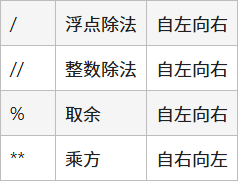

练习1

```python
#求圆的面积
radius=float(input("圆的半径为："))
area=3.14159*radius**2
print(f'半径为{radius}的圆的面积为：{area:.3f}') #大括号外是原文，括号里替换为相应的数值，同时可要求保留小数位数
```

练习2

```python
#计算时间差
#方法1
hour1,minute1=map(int,input('请输入时间1').split())
print(f'时间1为{hour1}:{minute1}')
hour2,minute2=map(int,input('请输入时间2').split())
print(f'时间2为{hour2}:{minute2}')
#map(int..)转化为整形
#split 默认空格分割字符串  split(',')按逗号分隔字符串
diff=hour2*60+minute2-(hour1*60+minute1)
print(f'时间差为{diff//60}时{diff%60}分')
#//取整 %取余
#方法2（判断）
hour1,minute1=map(int,input('请输入时间1').split())
print(f'时间1为{hour1}:{minute1}')
hour2,minute2=map(int,input('请输入时间2').split())
print(f'时间2为{hour2}:{minute2}')
diff_hour=hour2-hour1
diff_minute=minute2-minute1
if diff_minute<0:#这里要加一个冒号
   diff_minute += 60
   diff_hour -= 1
print(f'时间差为{diff_hour}时{diff_minute}分')
```

练习3

while True 重复执行 if...break 跳出循环

```python
#计算平均数
cnt=0
s=0
while True:
    x=int(input())
    if x==-1:
        break
    cnt+=1
    s+=x
print(s)
```

# 02 循环计算

1.除法

/是普通除法，//是整数除法。整数除法是取不大于除法结果的最大整数

2.取余

```python
print(5%3)
print(5//-3)
print(5%-3)
print(-5%3)
print(-5%-3)
```

3.取余应用

```python
#时间问题 1314分解为13:14
hour=1314//100
minute=1314%100
#整数分解 分离得到每一位
x1=256//100
x2=256//10%10 #x2=256%100//10
x3=256%10
```

练习1：数整数位数

```python
num=0
x=int(input("请输入目标整数"))
while True: #注意：：：
    if x==0: #层次
        break
    x=x//10
    num+=1
print(f'整数位数为：{num}')
```

4.赋值

```python
#连续赋值
a=b=5
print(a,b)
#同步赋值
a,b=4,6
print(a,b)
#交换变量的值
c=a
a=b
b=c
print(a,b)
#同步赋值交换
a,b=b,a
print(a,b)
```

练习2：最大公约数

```python
#初始版
a,b=map(int,input().split()) #空格分隔输入
while True:
    r=a%b
    if r==0:
        break
    a=b
    b=r
print(f'最大公约数为:{b}')
#核心背诵版
while b>0:
    a,b=b,a%b
print(a)
```

练习3：斐波那契

```python
n=int(input())
a,b=0,1
while a<n:
    print(a,end=',') #用逗号隔开
    a,b=b,a+b
```

5.if else

```python
#计算水费
x=float(input())
if x<=15:
    y=4*x/3
else:
    y=2.5*x-17.5
print(f'{y:.2f}') #保留两位小数
```

6.连缀的 if...elif...else

```python
#阶梯电价
x=float(input())
if x<=2760:
    y=0.538*x
elif x<=4800:
    y=0.588*x
else:
    y=0.838*x
#峰谷电价
```

练习4：

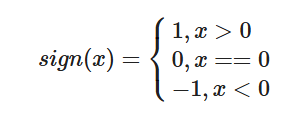

```python
x = int(input())
if x>0:
   r=1
elif x<0:
   r=-1
#else:    # 能否没有`else`？
#   r=0
print(r)
```

7.判断区间

and：与运算。当两个算子的值都是True的时候，结果才是True

or：或运算。当两个算子的值有一个是True的时候，结果就是True

not：非运算。当算子的值为False的时候，结果才是True

8.链式比较

形如 a op1 b op2 c，这里op1、op2是做比较的关系运算符，Python的计算规则是：a op1 b and b op2 c

```python
age=30
print(18 <=age <=45) #输出对错的
a,b,c=4,5,6
print(a == b == 5)
print(a <b ==c)
print(a > b < c)
```